# Zillow

## Predicting Home Market value

By Christian Freeman 2021-12-13

## Goals

My goal in this project is to:

- Identify the key Drivers of home prices and improve the baseline RSME.

## Executive Summary

### Findings Include:

- Original data size was 52,442
- After cleaning , dropping duplicates and outliers, I ended using 47892, about 91.3% of the data
- drivers of tax value are area(sqr ft), numbers of bedrooms, bathrooms and year built
- 2nd degree Polynomial Regression beat the baseline RSME by 54,361
- 2nd degree Polynomial RMSE is 264,859 with r2 of .3 ,and the mean baseline is 319220
- The log error has some outliers

```
<function explore.house_distro(df)>
```

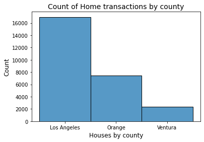

```python
### 2. Which County has the highest numbers of transactions for houses?
ex.house_distro(train)
```

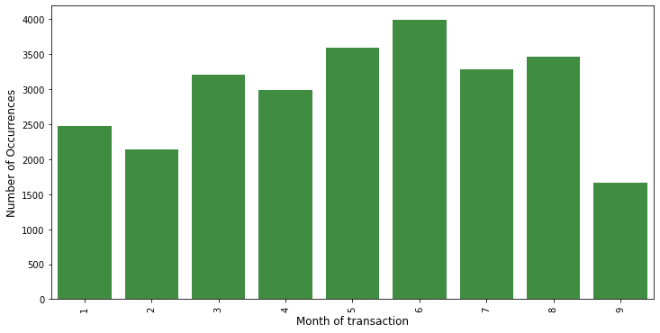

```
<function explore.monthly_distro(df)>
```

```python
# 3. Wich months has the highest number of transactions?
ex.monthly_distro(train)
```

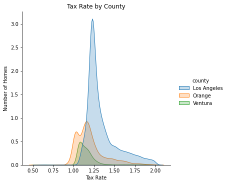

```
The max tax rate for all counties is 2.01 percent
```

```python
# 4 Is the tax rate the same in each county?
ex.tax_rate_distro(train)
print(f'The max tax rate for all counties is {round(df.tax_rate.max(),2)} percent')
```

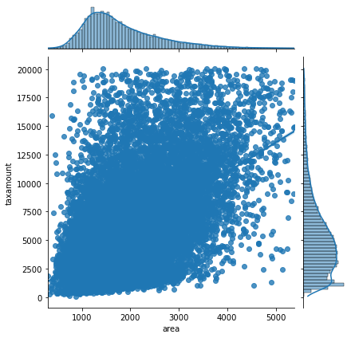

```python
sns.jointplot(x= train.area, y= train.taxamount, kind = 'reg')
```

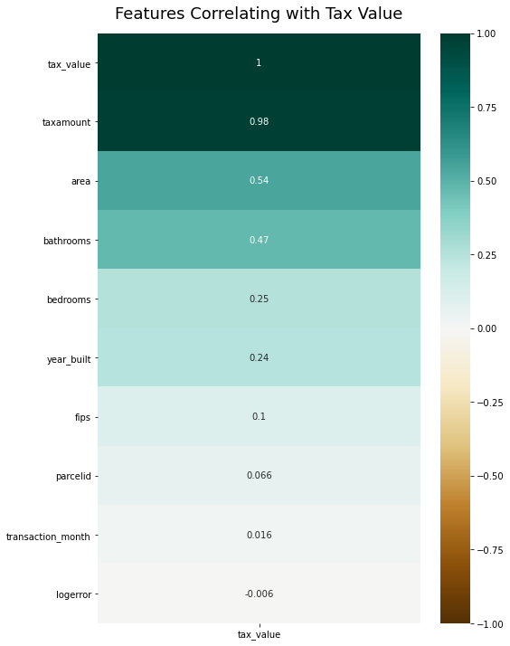

```python
#Make a heatmap that shows correlation of tax value and other continous variables
plt.figure(figsize=(8, 12))
heatmap = sns.heatmap(train.drop(columns=['tax_rate']).corr()[['tax_value']].sort_values(by='tax_value', ascending=False), vmin=-1, vmax=1, annot=True, cmap='BrBG')
heatmap.set_title('Features Correlating with Tax Value', fontdict={'fontsize':18}, pad=16);
```

## Hypotheses 1

- H0 : There is no correlation between the area and the tax value
- H1 : Area and tax value are correlated

## Hypotheses 2

- H0: The number of bedrooms per home is the same in all counties
- H1 : There is a difference in the number of bedrooms per home and the county location

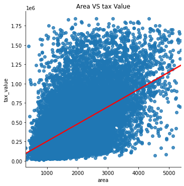

```
0.5417487780008441 and the p value is 0.0 We reject he null hypothesis
```

```python
# lets test 1
x = train.area
y= train.tax_value

corr, p = stats.pearsonr(x,y)

sns.lmplot(x= 'area',y= 'tax_value', data=train, line_kws={'color':'red'})
plt.title('Area VS tax Value')
plt.show()

print(f'{corr} and the p value is {p} We reject he null hypothesis')
```

```python
# lets test 2
observed = pd.crosstab(train.bedrooms, train.county)

chi2, p, degf, expected = stats.chi2_contingency(observed)

chi2, p
print(observed)
print(f'{chi2} and the p value is {p} We reject he null hypothesis')
```

```
county    Los Angeles  Orange  Ventura
bedrooms
1.0               237      59        6
2.0              3456     787      190
3.0              7998    3210      987
4.0              4176    2659      955
5.0               972     662      227
6.0               134      83       21
912.7807264021089 and the p value is 1.1301418531680415e-189 We reject he null hypothesis
```

## Modeling

After scalling I decided to test these different models on train and validate sets to evaluate their performance

- OLS
- LassoLars setting Alpha to 1
- 2 degree Polynomial regression

## BASELINE

RMSE using Mean Train/In-Sample: 319220

RMSE using Median Train/In-Sample: 326315

## Validate/Out-of-Sample: 330863

Moving foward our baseline to beat is mean. Model must get a RMSE of $319220

```python
metric_df
```

|  | model | RMSE_validate | r^2_validate |
| --- | --- | --- | --- |
| 0 | mean_baseline | 319220 | 0.000 |
| 1 | OLS Regressor | 271833 | 0.292 |
| 2 | Lasso Lars aplha:1 | 271832 | 0.292 |
| 3 | 2nd Degree Polynomial Regression | 269810 | 0.303 |

## Conclusion

- the area, year built, number of bedrooms and bathrooms are key drivers of home value
- Best performing model was 2nd degree polynomial
- Test Finished with r2 score of .3 and RMSE2 of 264,859 which was 54,361 more acurate than basline
- I believe there are a lot to unpack from this this dataset, and this model Definitely a steeping stone to handle this this dataset, an can be finetune with time.
- given more time i would work on engineering better features for better perfopmance